# Big Bang Chi-Squared Analysis

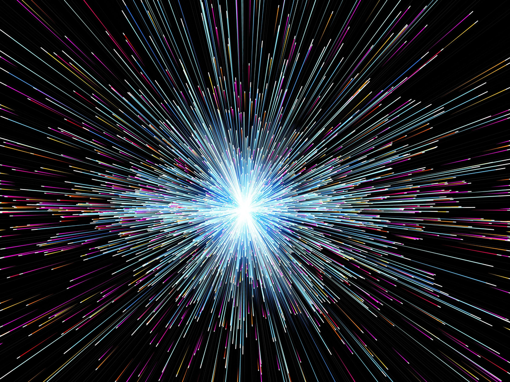

Image from [Wired (Pasieka/Getty Images)](https://www.wired.com/story/to-understand-the-universe-physicists-are-building-their-own/)

## Background

Using the data from the General Social Survey 1972-2012 Cumulative Datafile, we asked, “Are a person’s age range and belief in the Big Bang associated?”

A table was created from the GSS data using the respondent’s age and response to the following question:  
"Now, I would like to ask you a few short questions like those you might see on a television game show. For each statement that I read, please tell me if it is true or false. If you don’t know or aren’t sure, just tell me so, and we will skip to the next question. Remember true, false, or don’t know. g.

The universe began with a huge explosion. (Is that true or false?)"

This analysis includes only answers of true, false, and don’t know. If the value indicated that there wasn’t a response or the question was, for some reason, inappropriate. The row was removed.

## Analysis

#### Hypothesis

$$H_0:\ \text{ A person's age range and their belief in the Big Bang are independent.}$$

$$H_a:\ \text{A person's age range and their belief in the Big Bang are associated (not independent).}$$
$$\alpha = 0.05$$

#### Graphical and Numerical Summaries

The table below summarizes the responses of participants as grouped by age range:

```r
# Create palette

palette(c("#416ecc","#772ea4","#b52588","#e60d54","#f4c33e","#bd6127","#687652"))

# send table into the function
pander(table("Age"=AgeRange, Response))
```

|  | True | False | Don’t Know |
| --- | --- | --- | --- |
| **18 - 29** | 44 | 18 | 21 |
| **30 - 39** | 33 | 32 | 28 |
| **40 - 49** | 31 | 29 | 30 |
| **50 - 59** | 30 | 35 | 36 |
| **60 - 69** | 39 | 25 | 24 |
| **70 - 79** | 7 | 14 | 10 |
| **80 or Older** | 11 | 10 | 7 |

Notice, in the barplot, that the overall shape of the data is shaped differently. Some age ranges have more evenly divided responses than others. For example, in the 50 to 50 age range, the number of respondents for each answer are fairly similar, but for other age groups, like those in the 18-29 range, the differences in answers have more disparity.

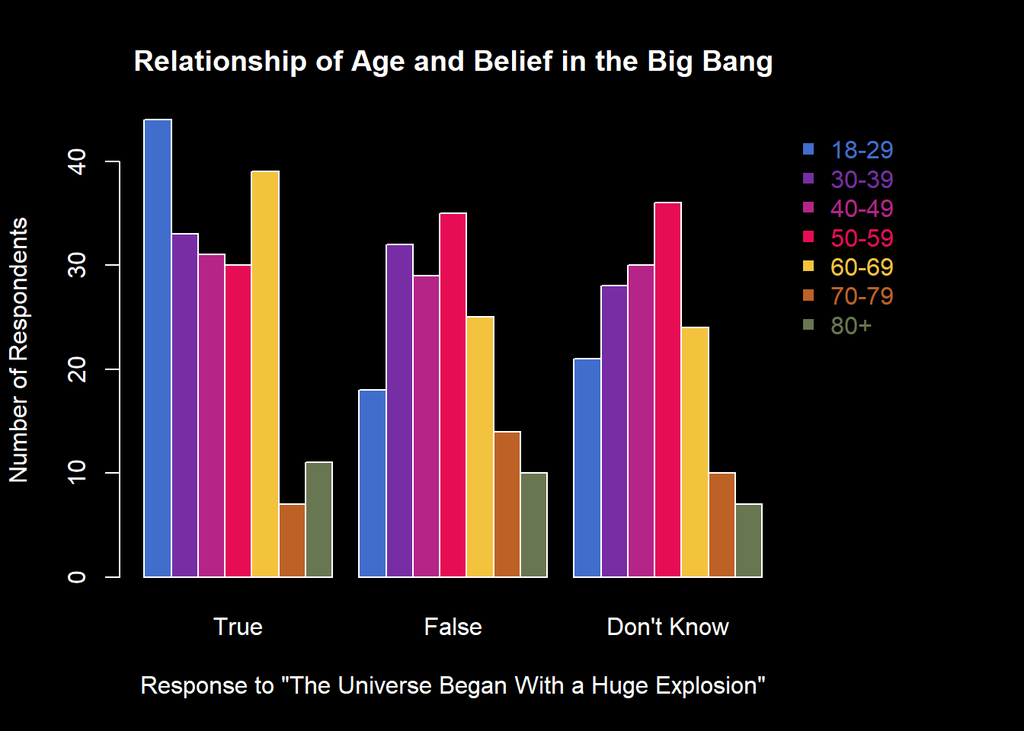

```r
# Or maybe these are better
# par(bg = 'black', fg = 'white')
par(bg = 'black', fg = 'white', xpd=T, mar=par()$mar+c(0,0,0,6))
barplot(table(AgeRange, Response), ylab="Number of Respondents", xlab = "Response to \"The Universe Began With a Huge Explosion\"", main = "Relationship of Age and Belief in the Big Bang", col=palette(), beside=TRUE, bty="n", col.axis= "white", col.lab="white", col.main="white")

legend("topleft", col=palette(), pch=15, legend=c("18-29", "30-39","40-49", "50-59","60-69","70-79","80+"), bty="n", text.col = palette(), inset=c(1,0), xpd=TRUE)
```

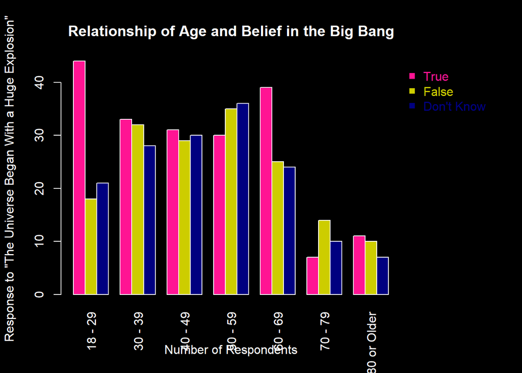

```r
palette(c("deeppink","yellow3","navyblue"))
barplot(table(Response, AgeRange), xlab="Number of Respondents", ylab = "Response to \"The Universe Began With a Huge Explosion\"", main = "Relationship of Age and Belief in the Big Bang", col=palette(), beside=TRUE, bty="n", col.axis= "white", col.lab="white", col.main="white", las=3)
legend("topleft", col=palette(), pch=15, legend=c("True", "False","Don't Know"), bty="n", text.col = palette(), inset=c(1,0), xpd=TRUE)
```

#### Chi-squared Test

To determine whether age range and belief in the Big Bang theory are associated. A chi-squared test was conducted.

```r
#null is independent
mychi <- chisq.test(table(AgeRange, Response))
# with a pvalue of whatever
pander(mychi)
```

Pearson’s Chi-squared test: `table(AgeRange, Response)`

| Test statistic | df | P value |
| --- | --- | --- |
| 17.91 | 12 | 0.1185 |

With a $p$-value of 0.1185, we can conclude that there is insufficient evidence to reject the null.

#### Assumptions

The requirement for the chi-squared test are met because all of the expected counts are greater than 5. We can assume the results of the test are accurate.

```r
# requiremnet
# should all be greater than five so requirement is met
pander(mychi$expected)
```

|  | True | False | Don’t Know |
| --- | --- | --- | --- |
| **18 - 29** | 31.49 | 26.32 | 25.19 |
| **30 - 39** | 35.28 | 29.49 | 28.23 |
| **40 - 49** | 34.14 | 28.54 | 27.32 |
| **50 - 59** | 38.32 | 32.03 | 30.65 |
| **60 - 69** | 33.39 | 27.91 | 26.71 |
| **70 - 79** | 11.76 | 9.831 | 9.409 |
| **80 or Older** | 10.62 | 8.879 | 8.498 |

```r
# Dig Deeper
# look at largest and smallest values this had a significantly higher (more counts than expected) negative means less counts
# pander(mychi$residuals)
# make sure to filter this out add
```

## Conclusion

The $p$-value of the chi-squared test was 0.1185. We have insufficient evidence to reject the null–a person’s age range and belief in the big bang are independent. As the expected counts were all greater than five the assumptions of the test were met, so the results of the test are valid.